# Atividade 02

# Exercício 1

## Classifique cada uma das variáveis de estudo

Identificação: variável qualitativa nominal;

Local: variável qualitativa nominal;

Presença de coliforme: variável qualitativa ordinal;

Nitrato: variável quantitativa contínua;

PH: variável quantitativa contínua;

# Exercício 2

Verifique a existência de pontos discrepantes de nitrato e PH por meio de gráficos e estatísticas descritivas. Realize a correção das informações implausíveis, visto que houve o esquecimento do ponto como erro de digitação.

*Resolução:* Carregando algumas bibliotecas.

```r
library(readxl)
library(dplyr)
```

```r
library(tidyr)
library(ggplot2)
```

Carregando os dados.

```r
df <- read_excel("Atividade02.xlsx")
names(df) <- c("ID","Local","Presenca","Nitrato","PH")
df <- drop_na(df)
summary(df)
```

```
##        ID           Local             Presenca            Nitrato
##  Min.   :10059   Length:191         Length:191         Min.   :  5.40
##  1st Qu.:11384   Class :character   Class :character   1st Qu.:  8.50
##  Median :12587   Mode  :character   Mode  :character   Median :  9.60
##  Mean   :12555                                         Mean   : 12.39
##  3rd Qu.:13756                                         3rd Qu.: 11.40
##  Max.   :14998                                         Max.   :116.00
##        PH
##  Min.   : 3.90
##  1st Qu.: 6.00
##  Median : 8.10
##  Mean   : 7.84
##  3rd Qu.:10.00
##  Max.   :11.10
```

Podemos visualizar se há pontos discrepantes no gráfico Boxplot.

Primeiramente em relação ao Nitrato:

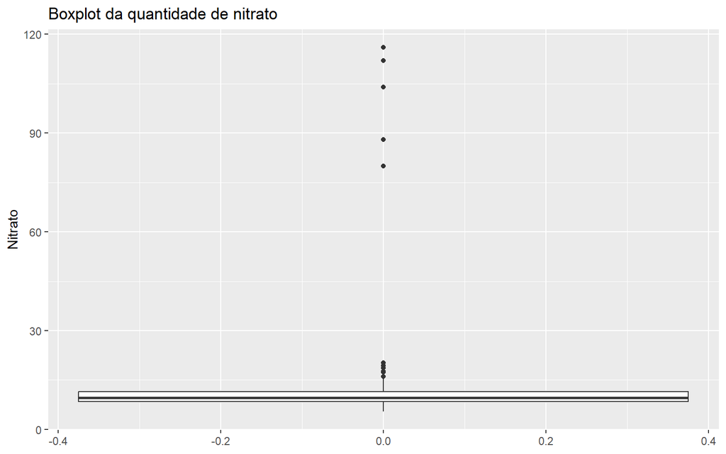

```r
ggplot(df,aes(y=Nitrato))+
  geom_boxplot()+
  labs(title = "Boxplot da quantidade de nitrato")
```

Em seguida em relação ao PH:

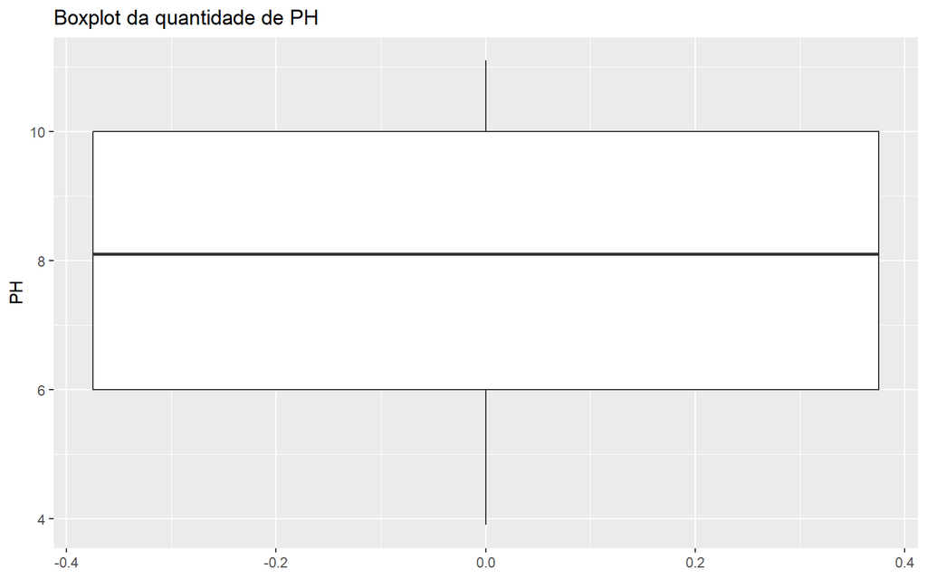

```r
ggplot(df,aes(y=PH))+
  geom_boxplot()+
  labs(title = "Boxplot da quantidade de PH")
```

Podemos observar que há vários outliers presentes na variável Nitrato enquanto que não há nenhum na variável PH.

Porém, apenas 5 pontos estão sendo extremamente discrepantes a ponto de considerarmos que tenham sido erros de digitação.

```r
df %>%
  arrange(desc(Nitrato)) %>%
  head(5)
```

```
## # A tibble: 5 × 5
##      ID Local        Presenca Nitrato    PH
##   <dbl> <chr>        <chr>      <dbl> <dbl>
## 1 11367 Lagoa Branca Presente     116  10
## 2 13082 Lagoa Santa  Ausente      112   6
## 3 13230 Lagoa Santa  Ausente      104   3.9
## 4 13476 Lagoa Santa  Presente      88  11
## 5 13583 Rio Bonito   Ausente       80   9.1
```

Dessa forma, podemos pensar na seguinte correção: pegamos os 5 maiores valores de nitrato e dividimos todos por 10, para acrescentar a vírgula onde possivelmente deveria ter sido colocada.

```r
df <- df %>%
  arrange(desc(Nitrato)) %>%
  mutate(Nitrato = ifelse(row_number() <= 5, Nitrato / 10, Nitrato))
```

Dessa forma, podemos visualizar o gráfico Boxplot do Nitrato novamente e veremos que a quantidade de outliers extremos diminuirá significativamente, embora que ainda tenham alguns.

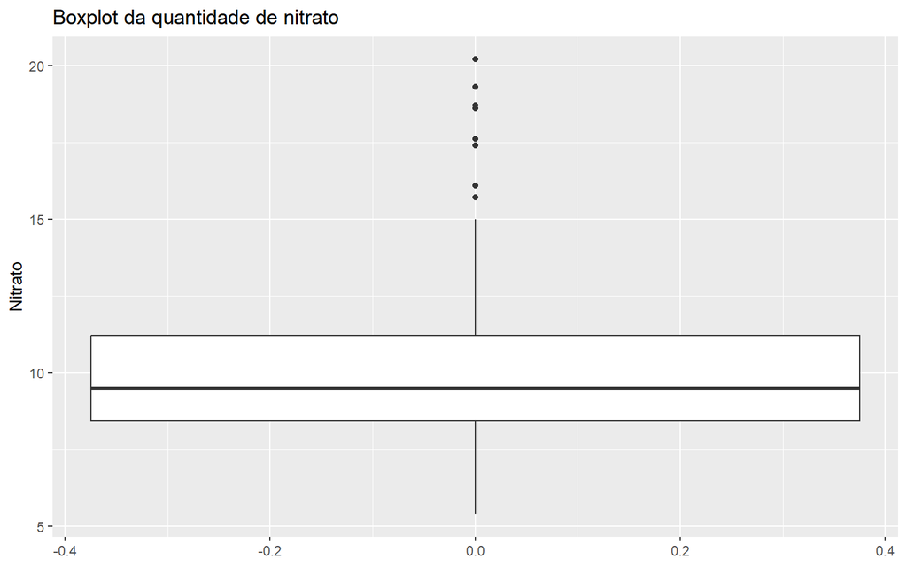

```r
ggplot(df,aes(y=Nitrato))+
  geom_boxplot()+
  labs(title = "Boxplot da quantidade de nitrato")
```

### 3 - As distribuições de amostras com coliformes entre os locais são diferentes? Avalie por meio de tabelas e gráficos.

Uma forma de podermos enxergar bem as distribuições é por meio dos histogramas.

```r
df %>%
  group_by(Local) %>%
  count()
```

```
## # A tibble: 5 × 2
## # Groups:   Local [5]
##   Local                     n
##   <chr>                 <int>
## 1 Bosque dos Jequitibás    38
## 2 Lagoa Branca             39
## 3 Lagoa Santa              38
## 4 Porto Alegre             38
## 5 Rio Bonito               38
```

Dessa forma, podemos construir histogramas baseados simplesmente na contagem, sem precisar trabalhar com porcentagens.

Assim, temos os seguintes histogramas:

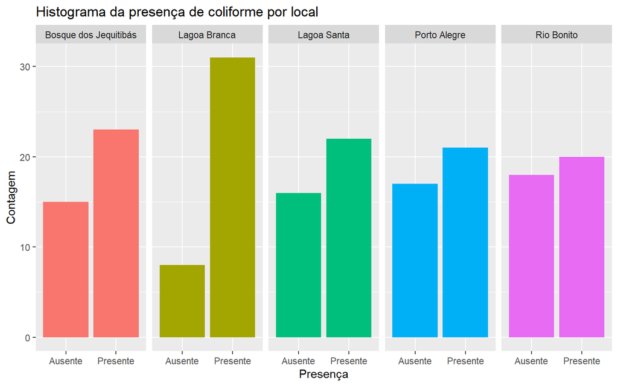

```r
ggplot(df,aes(x=Presenca, fill=Local))+
  geom_bar()+
  facet_grid(~Local)+
  labs(x = "Presença",y = "Contagem", title = "Histograma da presença de coliforme por local")+
  theme(legend.position = "none")
```

Apenas visualizando os gráficos, podemos notar que todos os locais são bem parecidos em relação à distribuição da presença de coliformes, com exceção da Lagoa Branca, que parece ter uma presença maior que as demais. Porém, qualquer afirmação deverá ser inferida por testes estatísticos eficientes.

### 4 - Construa o histograma e o box-plot do nitrato por local. Calcule as estatísticas descritivas como média, desvio-padrão, quartis do nitrato por local.

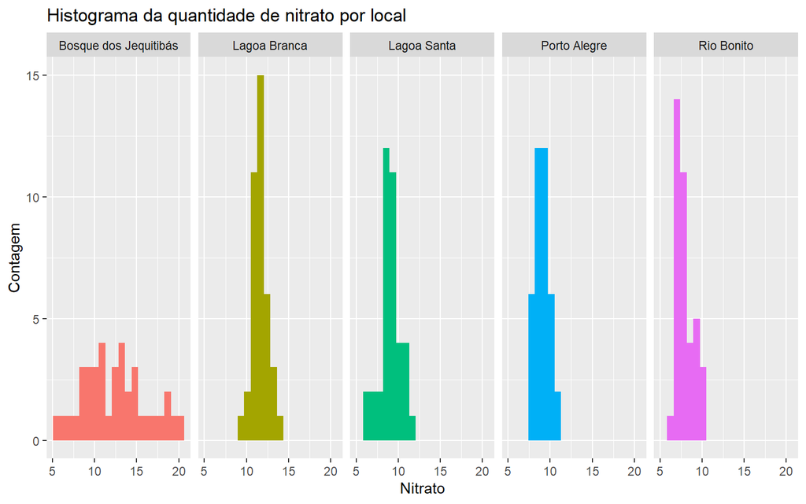

```r
ggplot(df,aes(x=Nitrato,fill = Local))+
  geom_histogram(bins=20)+
  facet_grid(~Local)+
  labs(x = "Nitrato",y = "Contagem", title = "Histograma da quantidade de nitrato por local")+
  theme(legend.position = "none")
```

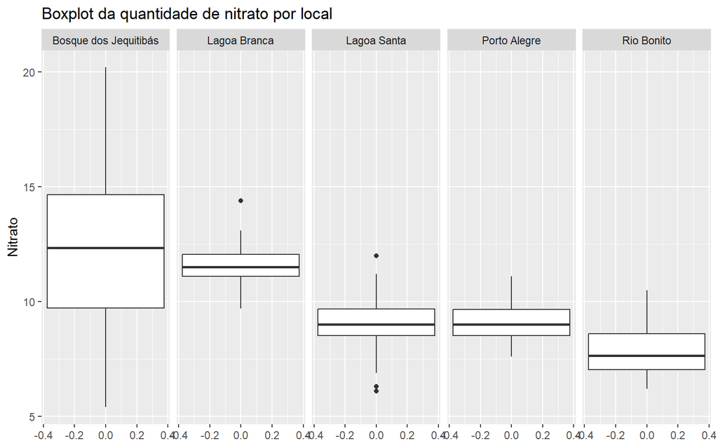

```r
ggplot(df,aes(y=Nitrato))+
  geom_boxplot()+
  facet_grid(~Local)+
  labs(y = "Nitrato", title = "Boxplot da quantidade de nitrato por local")
```

```r
df %>%
  group_by(Local) %>%
  summarise(media = mean(Nitrato),
            desvio_padrao = sd(Nitrato),
            primeiro_quartil = quantile(Nitrato, 0.25),
            mediana = median(Nitrato),
            terceiro_quartil = quantile(Nitrato, 0.75))
```

```
## # A tibble: 5 × 6
##   Local            media desvio_padrao primeiro_quartil mediana terceiro_quartil
##   <chr>            <dbl>         <dbl>            <dbl>   <dbl>            <dbl>
## 1 Bosque dos Jequ… 12.5          3.73              9.72   12.4             14.6
## 2 Lagoa Branca     11.6          0.918            11.1    11.5             12.0
## 3 Lagoa Santa       9.08         1.27              8.52    9                9.67
## 4 Porto Alegre      9.06         0.803             8.52    9                9.65
## 5 Rio Bonito        7.94         1.09              7.02    7.65             8.6
```

### 5 - Construa o histograma e o box-plot do PH por local. Calcule as estatísticas descritivas como média, desvio padrão, quartis do PH por local.

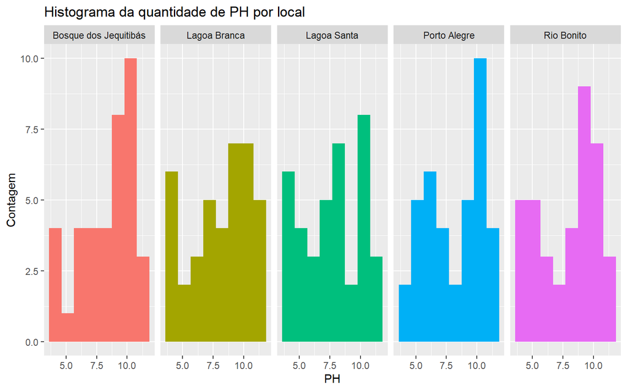

```r
ggplot(df,aes(x=PH,fill = Local))+
  geom_histogram(bins=8)+
  facet_grid(~Local)+
  labs(x = "PH",y = "Contagem", title = "Histograma da quantidade de PH por local")+
  theme(legend.position = "none")
```

[figure not shown]

```r
ggplot(df,aes(y=PH))+
  geom_boxplot()+
  facet_grid(~Local)+
  labs(y = "PH", title = "Boxplot da quantidade de nitrato por local")
```

```r
df %>%
  group_by(Local) %>%
  summarise(media = mean(PH),
            desvio_padrao = sd(PH),
            primeiro_quartil = quantile(PH, 0.25),
            mediana = median(PH),
            terceiro_quartil = quantile(PH, 0.75))
```

```
## # A tibble: 5 × 6
##   Local            media desvio_padrao primeiro_quartil mediana terceiro_quartil
##   <chr>            <dbl>         <dbl>            <dbl>   <dbl>            <dbl>
## 1 Bosque dos Jequ…  8.17          2.13             6.82    9                9.98
## 2 Lagoa Branca      7.86          2.35             6.2     8.1              9.9
## 3 Lagoa Santa       7.45          2.33             5.22    7.85             9.98
## 4 Porto Alegre      8.01          2.30             6       8.5             10
## 5 Rio Bonito        7.71          2.33             5.35    8.55             9.7
```